# 在R中进行预测模型的评价

当我们进行了模型的建立之后，需要对模型进行评价。这部分在论文中也是主要的部分之一。R作为一个完善和强大的统计软件，对于所有的模型都有一个较为统一的评价方法。

在这里，我们使用《R语言实践》第17章中所展示的内容进行logistic回归模型和随机森林的模型建立，并且通过不同的方法来比较模型的优异。至于随机森林和决策树，我将会在以后的内容中进行介绍，

## 数据集准备

我们这里使用的是威斯康星州乳腺癌数据集作为我们的训练和验证数据集。这部分的内容可以在《R语言实践》中找到。

首先我们需要下载这个数据集，并且将数据集随机分为训练集和验证集：

```r
loc <- "http://archive.ics.uci.edu/ml/machine-learning-databases/"
ds <- "breast-cancer-wisconsin/breast-cancer-wisconsin.data"
url <- paste(loc, ds, sep = "")
breast <- read.table(url, sep = ",", header = FALSE, na.strings = "?")
names(breast) <- c("ID", "clumpThickness", "sizeUniformity",
                   "shapeUniformity", "maginalAdhesion",
                   "singleEpithelialCellSize", "bareNuclei",
                   "blandChromatin", "normalNucleoli", "mitosis", "class")
df <- breast[-1]
df$class <- factor(df$class, levels = c(2, 4), labels = c("benign", "malignant"))
set.seed(1234)
train <- sample(nrow(df), 0.7 * nrow(df))
df.train <- df[train, ]
df.validate <- df[-train, ]
print(table(df.train$class))
```

```
##
##    benign malignant
##       329       160
```

```r
print(table(df.validate$class))
```

```
##
##    benign malignant
##       129        81
```

我们打印出两个数据集中恶性乳腺癌和良性乳腺癌的比例是否接近一致。如果存在很大程度的差异，我们可能要在`set.seed()`中重新选择一个随机种子数来进行抽样分组。

当然，可能使用百分比会更加直观一些：

```r
print(prop.table(table(df.train$class)))
```

```
##
##    benign malignant
## 0.6728016 0.3271984
```

```r
print(prop.table(table(df.validate$class)))
```

```
##
##    benign malignant
## 0.6142857 0.3857143
```

## 模型的建立

我们在这里建立logistic回归模型和随机森林模型来预测良性和恶性乳腺癌。

#### logistic 回归模型

logistic 回归是一种在医学领域中被广泛运用的模型，除了用来作为分类器以外，还可以用来寻找危险因素（使用OR来进行表示）。在R中，logistic 回归的模拟拟合是内置在basic中的，我们可以直接使用`glm()`进行拟合：

```r
fit.logit <- glm(class ~ ., data = df.train, family = binomial())
print(summary(fit.logit))
```

```
##
## Call:
## glm(formula = class ~ ., family = binomial(), data = df.train)
##
## Deviance Residuals:
##      Min        1Q    Median        3Q       Max
## -2.75813  -0.10602  -0.05679   0.01237   2.64317
##
## Coefficients:
##                           Estimate Std. Error z value Pr(>|z|)
## (Intercept)              -10.42758    1.47602  -7.065 1.61e-12 ***
## clumpThickness             0.52434    0.15950   3.287  0.00101 **
## sizeUniformity            -0.04805    0.25706  -0.187  0.85171
## shapeUniformity            0.42309    0.26775   1.580  0.11407
## maginalAdhesion            0.29245    0.14690   1.991  0.04650 *
## singleEpithelialCellSize   0.11053    0.17980   0.615  0.53871
## bareNuclei                 0.33570    0.10715   3.133  0.00173 **
## blandChromatin             0.42353    0.20673   2.049  0.04049 *
## normalNucleoli             0.28888    0.13995   2.064  0.03900 *
## mitosis                    0.69057    0.39829   1.734  0.08295 .
## ---
## Signif. codes:  0 '***' 0.001 '**' 0.01 '*' 0.05 '.' 0.1 ' ' 1
##
## (Dispersion parameter for binomial family taken to be 1)
##
##     Null deviance: 612.063  on 482  degrees of freedom
## Residual deviance:  71.346  on 473  degrees of freedom
##   (6 observations deleted due to missingness)
## AIC: 91.346
##
## Number of Fisher Scoring iterations: 8
```

#### 随机森林

**随机森林**是一种使用多个机器学习进行拟合的方法，他是决策树的一种特有方式。除此之外还有*bagging*和*Boosting*，这两种方法并不是一个机器学习算法特有的。具体的内容将会在以后讲决策树的模型建立中具体去讲。这里，我们仅仅去选择随机森林来建立模型。随机森林的函数我们可以在*randomForest*包中找到。如果你需要进行这一步，你需要确保自己的机器已经安装了这个包。如果没有安装，请使用`install.packages("randomForest")`进行安装。

```r
library(randomForest)
set.seed(1234)
fit.forest <- randomForest(class ~ ., data = df.train,
                           na.action = na.roughfix, importance = TRUE)
print(fit.forest)
```

```
##
## Call:
##  randomForest(formula = class ~ ., data = df.train, importance = TRUE,      na.action = na.roughfix)
##                Type of random forest: classification
##                      Number of trees: 500
## No. of variables tried at each split: 3
##
##         OOB estimate of  error rate: 3.48%
## Confusion matrix:
##           benign malignant class.error
## benign       320         9  0.02735562
## malignant      8       152  0.05000000
```

## 模型的评价

这样，我们就使用训练集建立了我们想要的分类器。现在我们需要用这个建好的分类器去验证集中验证和评价模型是否能够很好的把区分恶性乳腺癌和良性乳腺癌。

#### 模型预测

在R中，我们可以使用`predict()`函数进行模型的预测。

```r
logit.pred <- predict(fit.logit, df.validate, type = "response")
forest.pred <- predict(fit.forest, df.validate, type = "class")
print(head(logit.pred))
```

```
##           3           4           5           8          14          18
## 0.006402885 0.841424146 0.013774681 0.004145666 0.003148881 0.007721851
```

```r
print(head(forest.pred))
```

```
##         3         4         5         8        14        18
##    benign malignant    benign    benign    benign    benign
## Levels: benign malignant
```

logistic 回归模型的预测类型因为预测的是概率，所以我们需要选择*response*，而随机森林本来就是二分类器，所以我们选择了*class*，这里的`type`还可以传递*prob*，我们将在ROC曲线的绘制中，使用这个参数进行ROC的绘制。

#### 混淆矩阵

混淆矩阵是一种我们非常常用的方法来衡量模型的优异程度。在医学领域中经常听到的灵敏度和特异度便是由混淆矩阵计算得来的。关于混淆矩阵（confusion matrix）的更多内容，可以参看[wiki百科的内容](https://en.wikipedia.org/wiki/Confusion_matrix)，以及网站上优秀的[博文](https://www.cnblogs.com/wuliytTaotao/p/9285227.html)。由混淆矩阵我们计算很多评价模型的参数，如灵敏度、特异度、准确性等等。我们在这里，会使用*caret*包中的`confusionMatrix()`函数来获得混淆矩阵。

```r
library(caret)
print(confusionMatrix(forest.pred, df.validate$class, positive = "malignant"))
```

```
## Confusion Matrix and Statistics
##
##            Reference
## Prediction  benign malignant
##   benign       117         1
##   malignant      3        79
##
##                Accuracy : 0.98
##                  95% CI : (0.9496, 0.9945)
##     No Information Rate : 0.6
##     P-Value [Acc > NIR] : <2e-16
##
##                   Kappa : 0.9585
##
##  Mcnemar's Test P-Value : 0.6171
##
##             Sensitivity : 0.9875
##             Specificity : 0.9750
##          Pos Pred Value : 0.9634
##          Neg Pred Value : 0.9915
##              Prevalence : 0.4000
##          Detection Rate : 0.3950
##    Detection Prevalence : 0.4100
##       Balanced Accuracy : 0.9812
##
##        'Positive' Class : malignant
##
```

这里值得注意的是，`positive`参数需要我们去指定一个阳性的变量。这个将会影响到灵敏度和特异度等计算。在这里，我们认为这个模型是用于识别恶性肿瘤的，因此我们设定阳性为恶性肿瘤。

logistic 回归模型由于预测给的是概率，因此我们需要将其转换为二分类变量。

```r
logit.class <- factor(logit.pred > .5, levels = c(FALSE, TRUE),
                     labels = c("benign", "malignant"))
print(confusionMatrix(logit.class, df.validate$class, positive = "malignant"))
```

```
## Confusion Matrix and Statistics
##
##            Reference
## Prediction  benign malignant
##   benign       118         4
##   malignant      2        76
##
##                Accuracy : 0.97
##                  95% CI : (0.9358, 0.9889)
##     No Information Rate : 0.6
##     P-Value [Acc > NIR] : <2e-16
##
##                   Kappa : 0.9372
##
##  Mcnemar's Test P-Value : 0.6831
##
##             Sensitivity : 0.9500
##             Specificity : 0.9833
##          Pos Pred Value : 0.9744
##          Neg Pred Value : 0.9672
##              Prevalence : 0.4000
##          Detection Rate : 0.3800
##    Detection Prevalence : 0.3900
##       Balanced Accuracy : 0.9667
##
##        'Positive' Class : malignant
##
```

这样我们就得到了大部分衡量模型的参数细节。kappa值或许是一个需要花时间了解和掌握的一个统计量。他在数据不平衡的数据集较为重要。

#### ROC曲线

或许前面繁多的统计量在论文中不怎么见到，而ROC曲线在各个期刊论文中都可以看到，毕竟谁都喜欢可视化的图不是么？一般来讲，能够使用`predict()`函数进行预测的，我们都可以将其绘制成ROC曲线。在这里我们需要使用的包是*ROCR*，这个包提供了ROC的计算和AUC面积的计算。如果要在本地机器中实现接下来的步骤，请确保你的机器中已经安装了这个包，如果没有，请使用`install.packages("ROCR")`来进行安装。

```r
library(ROCR)
```

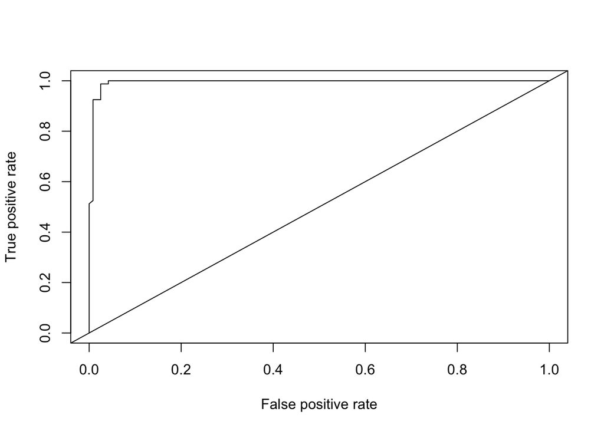

```r
forest.prob <- predict(fit.forest, df.validate, type = "prob")
forest.predt <- prediction(predictions = forest.prob[ , 2],
                   labels = df.validate$class)
forest.perf <- performance(forest.predt, measure = "tpr", x.measure = "fpr")
plot(forest.perf)
abline(a = 0, b = 1)
```

```r
print(round(performance(forest.predt, "auc")@y.values[[1]], 4))
```

```
## [1] 0.9945
```

这样，我们就绘制出了ROC曲线，在`performance()`函数中，我们传递了`measure = "tpr"`，即真阳性率（True positive rate）作为Y轴，使用假阳性率（False positive rate）作为X轴。这种表现方式在医学领域中较为少见，我们通常使用灵敏度和1-特异度来作为ROC曲线的Y轴和X轴。在`performace()`函数中，提供了`measure = "sens"`和`x.measure = "spec"`来计算灵敏度和特异度。

曲线下面积的计算也是通过`performace()`函数进行的，我们可以使用`performance(forest.predt, "auc")@y.values[[1]]`提取出AUC的值。

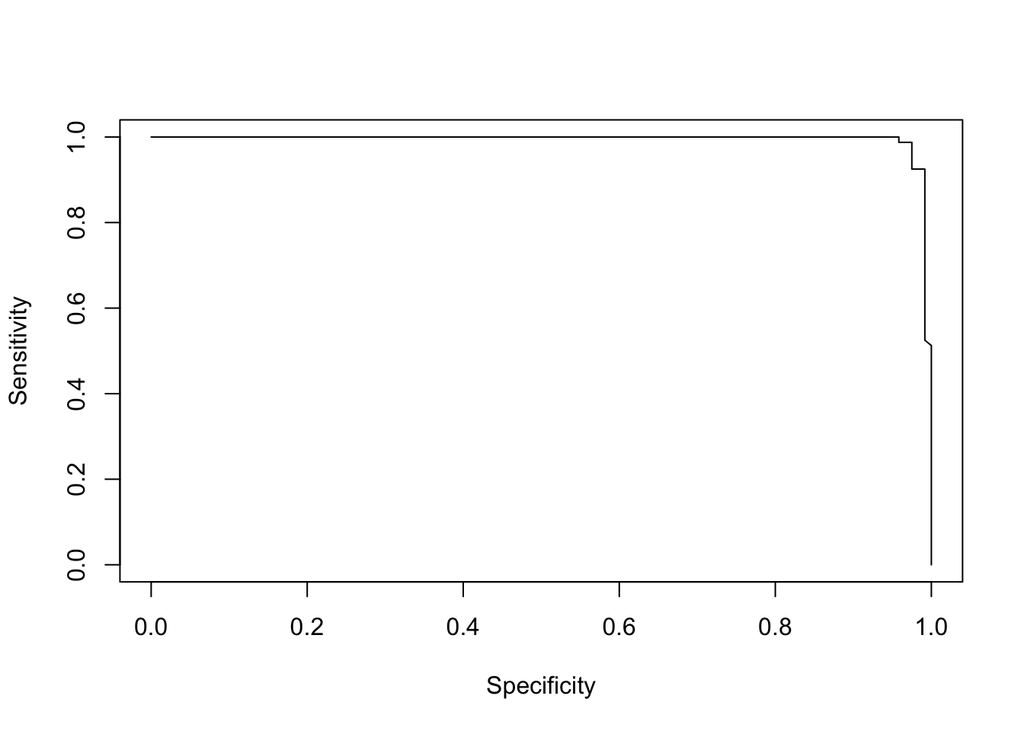

```r
forest.perf <- performance(forest.predt, measure = "sens", x.measure = "spec")
plot(forest.perf)
```

这时，我们可以看到它绘制了一个反过来的曲线，这是因为我们使用的是特异度而不是1-特异度。

同时，我们或许还需要将logistic回归的ROC曲线和随机森林的ROC曲线放到一块儿进行对比，然后还要在图中标记两种模型的AUC面积。这时，我们可能需要一点小小的创新来实现我们的目标。

**对于绘制ROC曲线来说，其实我们需要知道Y轴（灵敏度）和X轴（1-特异度）的值我们就可以使用很多自己想要的方式来绘制了。**而这个关键是，我们需要知道`performace()`函数输出了什么。

```r
forest.perf <- performance(forest.predt, measure = "sens", x.measure = "spec")
print(unclass(forest.perf))
```

```
## <S4 Type Object>
## attr(,"x.name")
## [1] "Specificity"
## attr(,"y.name")
## [1] "Sensitivity"
## attr(,"alpha.name")
## [1] "Cutoff"
## attr(,"x.values")
## attr(,"x.values")[[1]]
##  [1] 1.0000000 1.0000000 1.0000000 1.0000000 1.0000000 1.0000000 1.0000000
##  [8] 1.0000000 1.0000000 1.0000000 1.0000000 1.0000000 1.0000000 1.0000000
## [15] 1.0000000 1.0000000 1.0000000 0.9916667 0.9916667 0.9916667 0.9916667
## [22] 0.9916667 0.9916667 0.9916667 0.9916667 0.9916667 0.9916667 0.9916667
## [29] 0.9916667 0.9916667 0.9916667 0.9916667 0.9916667 0.9916667 0.9916667
## [36] 0.9916667 0.9916667 0.9916667 0.9916667 0.9916667 0.9916667 0.9916667
```

[output cut: 26 more lines]

这样，我们就看到了我们想要的信息：

- S4 type object：这是R标准的面向对象实现方式。emmmm……，这么讲不容易懂，这里只要知道的是，和**list**不同，提取出S4类型的数据我们不再使用`$`而是使用`@`。
- x.name：Specificity，这个项目的值就是我们的X轴的值。什么？你说X轴是1-specificity？额，提取出来自己减一下不就完了？
- y.name: Sensitivity，这和上边的一样，但是他们俩都是一个字符串，我们真正需要的值在*x.values*和*y.values*中。

这样，我们思路明确了，将`performace()`函数输出的*x.values*和*y.values*提取出来，放到我们自己创建的数据框中，然后使用ggplot进行绘制ROC曲线。这样，我们就可以为所欲为啦。

当然，我们最终的目标是要把两个ROC曲线放一块儿的。这是我们需要额外的一列来指明*x.values*和*y.values*是哪个模型中的。接下来看代码吧：

```r
library(ROCR)
forest.prob <- predict(fit.forest, df.validate, type = "prob")
forest.predt <- prediction(predictions = forest.prob[ , 2],
                   labels = df.validate$class)
forest.perf <- performance(forest.predt, measure = "sens", x.measure = "spec")
logit.predt <- prediction(logit.pred, df.validate$class)
logit.perf <- performance(logit.predt, measure = "sens", x.measure = "spec")
df.forest <- data.frame("model" = "randomforest",
                        "Specificity" = 1 - forest.perf@x.values[[1]],
                        "Sensitivity" = forest.perf@y.values[[1]])

df.logit <- data.frame("model" = "logistic",
                       "Specificity" = 1 - logit.perf@x.values[[1]],
                       "Sensitivity" = logit.perf@y.values[[1]])
df.roc <- rbind(df.forest, df.logit)
logit.auc <- round(performance(logit.predt, "auc")@y.values[[1]], 4)
forest.auc <- round(performance(forest.predt, "auc")@y.values[[1]], 4)
print(df.roc[c(1:3, 73:75), ])
```

```
##           model Specificity Sensitivity
## 1  randomforest           0      0.0000
## 2  randomforest           0      0.1250
## 3  randomforest           0      0.2125
## 73     logistic           0      0.0000
## 74     logistic           0      0.0125
## 75     logistic           0      0.0250
```

我们挑了几行看下，发现已经把两个模型的结果合并起来了。同时我们也提取出了两个模型的曲线下面积，现在万事俱备，就差画图了，这里我们使用*ggplot2*包来进行画图。

要进行下面的步骤，请确保机器安装了*ggplot2*和*ggthemes*包，如果没有，请使用`intall.packages("ggplot2")`和`intall.packages("ggthemes")`安装这两个包。

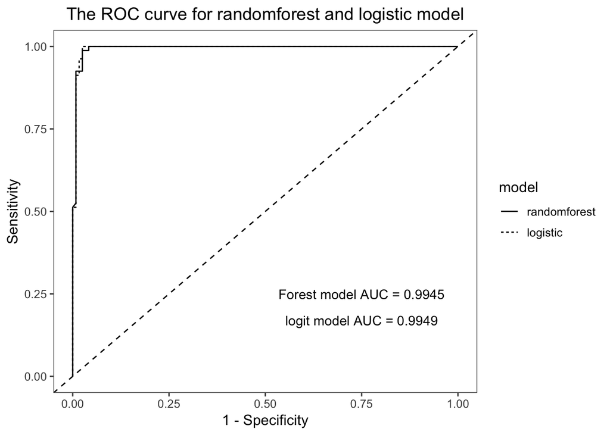

```r
library(ggplot2)
library(ggthemes)
ggplot(df.roc, aes(x = Specificity, y = Sensitivity,
                   linetype = model, group = model)) +
    geom_line() + geom_abline(intercept = 0, slope = 1, linetype = "dashed") +
    xlab("1 - Specificity") +
    theme_few() +
    annotate("text", x = 0.75, y = 0.25,
             label = paste0("Forest model", " AUC = ", forest.auc)) +
    annotate("text", x = 0.75, y = 0.17,
             label = paste0("logit model", " AUC = ", logit.auc)) +
    ggtitle("The ROC curve for randomforest and logistic model") +
    theme(plot.title = element_text(hjust = 0.5))
```

这样子的图是不是比原来的好些了？

当然，*ggplot2*包中还有很多个性化的调整方法，作出更加漂亮的图形。我在这里就随便调整下，能看就行不是么？

### 还没有实现的

由于这次讲的是模型评价，并没有去实现Cutoff值，约登指数在图形中的绘制。当然也主要因为自己懒。有时间会在这个基础上去实现约登指数的表现。

当然，这里还有一个问题尚未解决：**两个模型AUC的统计推断**。这部分我得去扒下别人的代码，看看到底是使用什么方法做这个统计推断的。

这次使用的是RMarkdown写的文档，我会把这个文件放在邮件的附件里的。大家可以在Rstudio中打开它。